# GIPR statistical analysis 5vv

Erik Ländström

8 March 2019

Read libraries.

```r
library(tidyverse)
library(modelr)
library(broom)
library(ggfortify)
library(sva)
library(qvalue)
```

Read functions.

# Analysis

Perform statistical analysis of imputed data with at least 5 valid values per group.

Read data.

```r
data <- read_tsv("GIPR_liraglutide_liver_5vv_imputed.tsv")
```

Separate conditions into separate columns.

```r
factored_data <- separate_condition_from_DEP_output(data, c("treatment", "gender", "series", "litter"), remove = FALSE)
```

## Linear model

Nest data.

```r
nested_data <- factored_data %>%
  group_by(name) %>%
  nest()
```

Linear model function.

```r
protein_model <- function(tb) {
  lm(LFQ ~ gender * litter, data = tb)
}
```

Perform linear regression on each protein and calculate/extract residuals.

```r
nested_model_data <- nested_data %>%
  mutate(model = map(data, protein_model))

nested_resids_data <- nested_model_data %>%
  mutate(resids = map2(data, model, add_residuals))

resids <- unnest(nested_resids_data, resids)
```

Calculate variance and compare with original data.

```r
variance <- resids %>%
  group_by(name) %>%
  summarise(var_lfq = var(LFQ),
            var_resid = var(resid))

variance %>%
  summarise(mean_lfq = mean(var_lfq),
            mean_resid = mean(var_resid))
```

```
## # A tibble: 1 x 2
##   mean_lfq mean_resid
##      <dbl>      <dbl>
## 1    0.273      0.144
```

```r
# Test if the regression reduced the variance for all proteins
variance %>%
  mutate(smaller = if_else(var_resid < var_lfq, 1, 0)) %>%
  summarise(n = sum(smaller),
            all = n())
```

```
## # A tibble: 1 x 2
##       n   all
##   <dbl> <int>
## 1  2611  2611
```

```r
resids %>%
  group_by(name, treatment) %>%
  summarise(var_lfq = var(LFQ),
            var_resid = var(resid))
```

```
## # A tibble: 5,222 x 4
## # Groups:   name [?]
##    name  treatment var_lfq var_resid
##    <chr> <chr>       <dbl>     <dbl>
##  1 A1BG  L         0.477     0.198
##  2 A1BG  P         0.255     0.0872
##  3 A1CF  L         0.00643   0.00311
##  4 A1CF  P         0.0186    0.00439
##  5 A2M   L         0.453     0.304
##  6 A2M   P         0.321     0.134
##  7 AACS  L         0.120     0.122
##  8 AACS  P         0.218     0.0594
##  9 AADAC L         0.0302    0.0624
## 10 AADAC P         0.0592    0.0445
## # ... with 5,212 more rows
```

The linear model decreased the variance for every protein!

## PCA

Unite replicate (ID) with condition (grouping), and spread to intensities into separate columns for each sample.

```r
lfq_for_pca <- resids %>%
  dplyr::select(name, replicate, condition, LFQ) %>%
  unite(replicate, replicate, condition) %>%
  spread(key = "replicate", value = "LFQ")

resids_for_pca <- resids %>%
  dplyr::select(name, replicate, condition, resid) %>%
  unite(replicate, replicate, condition) %>%
  spread(key = "replicate", value = "resid")
```

Perform PCA for both LFQ and residuals.

```r
lfq_pca <- format_data_for_PCA(lfq_for_pca, 17, c("sample", "treatment", "gender", "series", "litter"))
resid_pca <- format_data_for_PCA(resids_for_pca, 17, c("sample", "treatment", "gender", "series", "litter"))
```

Calculate the variance explained by each principal component for original and data processed with linear regression.

```r
# Calculate the variance that each PC explains
lfq_var_exp <- calculate_variance_explained(lfq_pca)
make_var_exp_kable(lfq_var_exp)
```

Proportion of the variance that each principal component explains

| PC | Variance | Proportion explained | Cumulative proportion explained |
| --- | --- | --- | --- |
| 1 | 450.4394 | 0.1725 | 0.1725 |
| 2 | 302.6057 | 0.1159 | 0.2884 |
| 3 | 210.7004 | 0.0807 | 0.3691 |
| 4 | 193.2114 | 0.0740 | 0.4431 |
| 5 | 167.4022 | 0.0641 | 0.5072 |
| 6 | 155.7387 | 0.0596 | 0.5669 |
| 7 | 145.5238 | 0.0557 | 0.6226 |
| 8 | 133.9327 | 0.0513 | 0.6739 |
| 9 | 129.1350 | 0.0495 | 0.7234 |
| 10 | 119.7712 | 0.0459 | 0.7692 |
| 11 | 115.7007 | 0.0443 | 0.8135 |
| 12 | 108.5180 | 0.0416 | 0.8551 |
| 13 | 100.9678 | 0.0387 | 0.8938 |
| 14 | 99.0919 | 0.0380 | 0.9317 |
| 15 | 90.0665 | 0.0345 | 0.9662 |
| 16 | 88.1947 | 0.0338 | 1.0000 |
| 17 | 0.0000 | 0.0000 | 1.0000 |

```r
resid_var_exp <- calculate_variance_explained(resid_pca)
make_var_exp_kable(resid_var_exp)
```

Proportion of the variance that each principal component explains

| PC | Variance | Proportion explained | Cumulative proportion explained |
| --- | --- | --- | --- |
| 1 | 514.2609 | 0.1970 | 0.1970 |
| 2 | 437.5550 | 0.1676 | 0.3645 |
| 3 | 292.9518 | 0.1122 | 0.4767 |
| 4 | 286.6988 | 0.1098 | 0.5865 |
| 5 | 244.5556 | 0.0937 | 0.6802 |
| 6 | 241.0802 | 0.0923 | 0.7725 |
| 7 | 209.5177 | 0.0802 | 0.8528 |
| 8 | 196.7997 | 0.0754 | 0.9282 |
| 9 | 187.5803 | 0.0718 | 1.0000 |
| 10 | 0.0000 | 0.0000 | 1.0000 |
| 11 | 0.0000 | 0.0000 | 1.0000 |
| 12 | 0.0000 | 0.0000 | 1.0000 |
| 13 | 0.0000 | 0.0000 | 1.0000 |
| 14 | 0.0000 | 0.0000 | 1.0000 |
| 15 | 0.0000 | 0.0000 | 1.0000 |
| 16 | 0.0000 | 0.0000 | 1.0000 |
| 17 | 0.0000 | 0.0000 | 1.0000 |

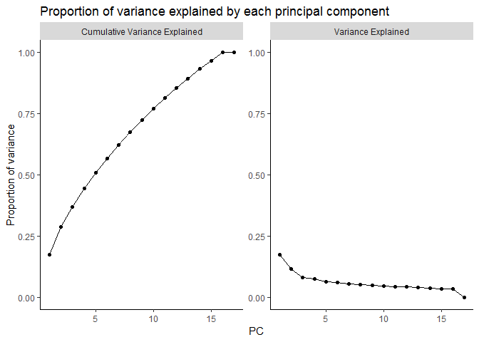

```r
# Plot variance explained plots
plot_var_exp(lfq_var_exp)
```

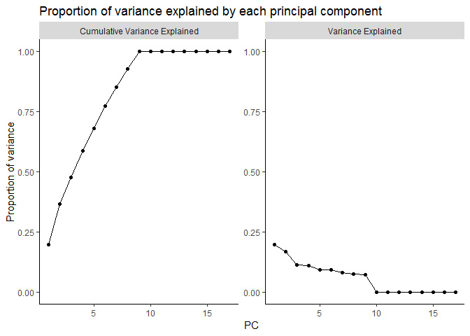

```r
plot_var_exp(resid_var_exp)
```

The principal components from the linear model explains considerably more of the variance than the LFQ intensities.

Plot the first two PCs of the PCA.

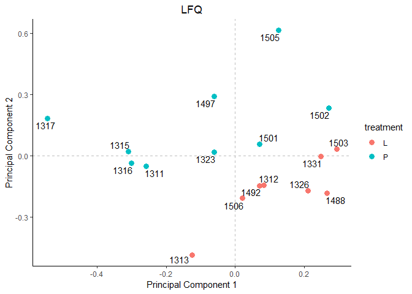

```r
plot_pca(lfq_pca, "LFQ", "treatment")
```

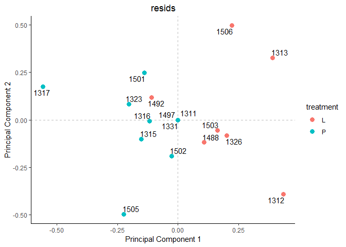

```r
plot_pca(resid_pca, "resids", "treatment")
```

Plot PC1 to PC4.

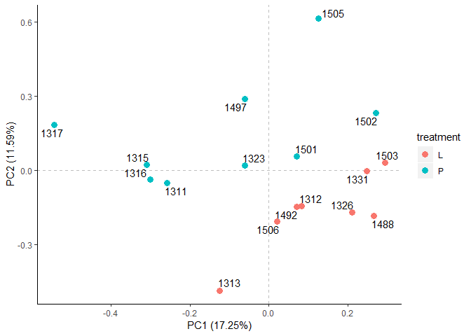

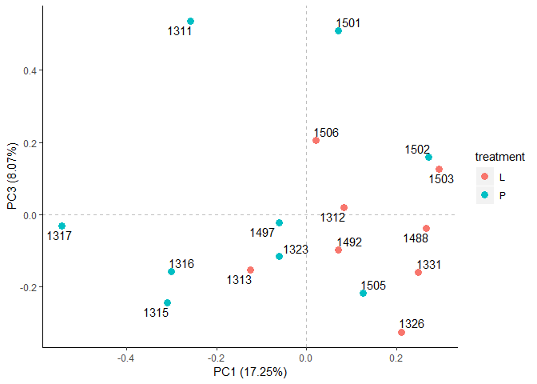

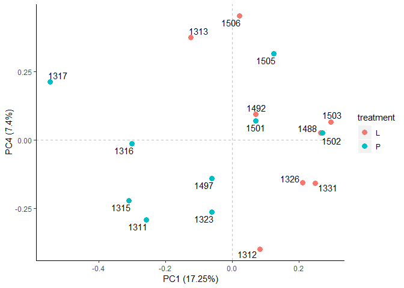

```r
plot_multiple_PCAs(lfq_pca, 1, 4, "treatment")
```

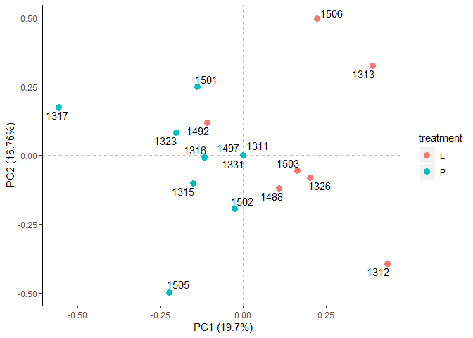

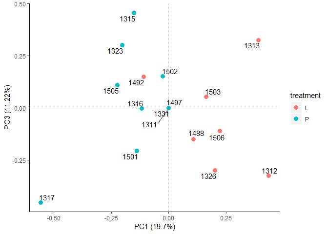

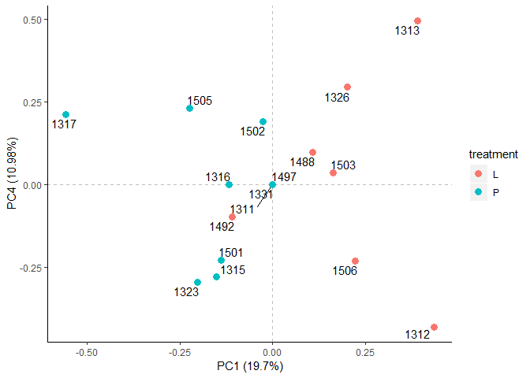

```r
plot_multiple_PCAs(resid_pca, 1, 4, "treatment")
```

# Surrogate variable analysis

Format data for sva.

Create expression data.

```r
exp_data <- resids %>%
  dplyr::select(name, replicate, LFQ) %>%
  spread(key = "replicate", value = "LFQ")

row.names(exp_data) <- exp_data$name
exp_data <- exp_data %>%
  dplyr::select(-name)
```

Create phenotypic data.

```r
pheno_data <- resids %>%
  dplyr::select(treatment, gender, series, litter, replicate) %>%
  distinct() %>%
  mutate(sample = row_number())

rownames(pheno_data) <- pheno_data$replicate
pheno_data <- pheno_data %>%
  dplyr::select(sample, treatment, gender, series, litter)
```

Create linear models, full and null model.

```r
mod = model.matrix(~ as.factor(treatment), data = pheno_data)

mod0 = model.matrix(~ 1,data = pheno_data)
```

Sva using LFQ values

```r
svobj = sva(as.matrix(exp_data), mod, mod0, n.sv= 2)
```

```
## Number of significant surrogate variables is:  2
## Iteration (out of 5 ):1  2  3  4  5
```

```r
svobj[[1]]
```

```
##              [,1]        [,2]
##  [1,]  0.28121621 -0.32240858
##  [2,]  0.12085909  0.08103956
##  [3,]  0.32955982 -0.33477472
##  [4,]  0.31803672  0.13682510
##  [5,]  0.20249532  0.19872057
##  [6,]  0.31024047  0.38598444
##  [7,]  0.17506837 -0.03399454
##  [8,] -0.14610477  0.03295110
##  [9,] -0.08279752  0.17625184
## [10,] -0.18480657 -0.10680021
## [11,]  0.07074298 -0.07001630
## [12,]  0.05278217  0.20590248
## [13,] -0.22228838 -0.26804769
## [14,] -0.33120371  0.05219279
## [15,] -0.33161042 -0.23091697
## [16,] -0.40640025  0.46423540
## [17,] -0.15578952 -0.36714426
```

Sva using LFQ plus the known batch effects: gender and series.

```r
mod = model.matrix(~ as.factor(treatment) * as.factor(gender) * as.factor(series), data = pheno_data)

mod0 = model.matrix(~ as.factor(gender) * as.factor(series),data = pheno_data)

svobj = sva(as.matrix(exp_data), mod, mod0, n.sv= 2)
```

```
## Number of significant surrogate variables is:  2
## Iteration (out of 5 ):1  2  3  4  5
```

```r
svobj[[1]]
```

```
##             [,1]        [,2]
##  [1,]  0.3205847 -0.25132052
##  [2,]  0.1688711  0.11124770
##  [3,] -0.1278212 -0.59875472
##  [4,] -0.2325753 -0.27956608
##  [5,] -0.2342868 -0.13889789
##  [6,]  0.1903921  0.18744818
##  [7,] -0.2605272 -0.29652097
##  [8,]  0.1921298  0.20590660
##  [9,] -0.2666725  0.19462981
## [10,]  0.1491838  0.09577549
## [11,]  0.1481339 -0.03091534
## [12,]  0.1605083  0.12540432
## [13,]  0.2184897  0.08806001
## [14,] -0.3128468  0.12628874
## [15,]  0.1190174  0.12595411
## [16,] -0.4867301  0.43553185
## [17,]  0.2541492 -0.10027129
```

Sva analysis using residuals from linear model.

```r
exp_resids <- resids %>%
  dplyr::select(name, replicate, resid) %>%
  spread(key = "replicate", value = "resid")

row.names(exp_resids) <- exp_resids$name
exp_resids <- exp_resids %>%
  dplyr::select(-name)

mod = model.matrix(~ as.factor(treatment), data = pheno_data)

mod0 = model.matrix(~ 1,data = pheno_data)

svobj = sva(as.matrix(exp_resids), mod, mod0, n.sv= 2)
```

```
## Number of significant surrogate variables is:  2
## Iteration (out of 5 ):1  2  3  4  5
```

```r
svobj[[1]]
```

```
##                [,1]          [,2]
##  [1,]  4.342562e-16 -1.345525e-15
##  [2,] -1.450184e-01 -2.865308e-02
##  [3,]  3.107872e-01 -4.632327e-01
##  [4,]  5.423766e-02 -1.905271e-01
##  [5,]  5.666220e-03 -3.006328e-02
##  [6,] -2.256727e-01  7.124762e-01
##  [7,]  2.624369e-01 -7.559128e-02
##  [8,] -2.624369e-01  7.559128e-02
##  [9,] -2.542256e-16  3.062080e-16
## [10,] -1.033075e-01  8.761065e-02
## [11,]  1.033075e-01 -8.761065e-02
## [12,] -8.395223e-17  1.885715e-16
## [13,]  3.888464e-01  2.244531e-01
## [14,] -3.937661e-01 -2.817511e-01
## [15,]  4.919751e-03  5.729805e-02
## [16,] -4.260929e-01 -1.999281e-01
## [17,]  4.260929e-01  1.999281e-01
```

```r
sv_factor1 <- tibble(replicate = as.numeric(rownames(pheno_data)),
       sv1 = svobj[[1]][, 1])
```

Join sva factor sv1 with previous results.

```r
resids_sv <- full_join(resids, sv_factor1, by = "replicate")
```

Nest data.

```r
nested_data <- resids_sv %>%
  group_by(name) %>%
  rename(resid_old = resid) %>%
  nest()
```

Linear model including the sv1 factor.

```r
protein_model <- function(tb) {
  lm(resid_old ~ sv1, data = tb)
}
```

Perform linear model.

```r
nested_model_data <- nested_data %>%
  mutate(model = map(data, protein_model))

nested_resids_data <- nested_model_data %>%
  mutate(resids = map2(data, model, add_residuals))

residuals_sv <- unnest(nested_resids_data, resids)
```

Calculate variance.

```r
variance <- resids %>%
  group_by(name) %>%
  summarise(var_lfq = var(LFQ),
            var_resid = var(resid))

variance %>%
  summarise(mean_var_lfq = mean(var_lfq),
            mean_var_resid = mean(var_resid))
```

```
## # A tibble: 1 x 2
##   mean_var_lfq mean_var_resid
##          <dbl>          <dbl>
## 1        0.273          0.144
```

```r
variance %>%
  mutate(smaller = if_else(var_resid < var_lfq, 1, 0)) %>%
  summarise(n = sum(smaller))
```

```
## # A tibble: 1 x 1
##       n
##   <dbl>
## 1  2611
```

```r
resids %>%
  group_by(name, treatment) %>%
  summarise(var_lfq = var(LFQ),
            var_resid = var(resid))
```

```
## # A tibble: 5,222 x 4
## # Groups:   name [?]
##    name  treatment var_lfq var_resid
##    <chr> <chr>       <dbl>     <dbl>
##  1 A1BG  L         0.477     0.198
##  2 A1BG  P         0.255     0.0872
##  3 A1CF  L         0.00643   0.00311
##  4 A1CF  P         0.0186    0.00439
##  5 A2M   L         0.453     0.304
##  6 A2M   P         0.321     0.134
##  7 AACS  L         0.120     0.122
##  8 AACS  P         0.218     0.0594
##  9 AADAC L         0.0302    0.0624
## 10 AADAC P         0.0592    0.0445
## # ... with 5,212 more rows
```

Calculate variance explained.

```r
resids_sv_for_pca <- residuals_sv %>%
  dplyr::select(name, replicate, condition, resid) %>%
  unite(replicate, replicate, condition) %>%
  spread(key = "replicate", value = "resid")

resid_sv_pca <- format_data_for_PCA(resids_sv_for_pca, 17, c("sample", "treatment", "gender", "series", "litter"))

resid_sv_var_exp <- calculate_variance_explained(resid_sv_pca)
make_var_exp_kable(resid_sv_var_exp)
```

Proportion of the variance that each principal component explains

| PC | Variance | Proportion explained | Cumulative proportion explained |
| --- | --- | --- | --- |
| 1 | 579.1862 | 0.2218 | 0.2218 |
| 2 | 387.5179 | 0.1484 | 0.3702 |
| 3 | 350.5730 | 0.1343 | 0.5045 |
| 4 | 297.1915 | 0.1138 | 0.6183 |
| 5 | 283.6084 | 0.1086 | 0.7270 |
| 6 | 258.3997 | 0.0990 | 0.8259 |
| 7 | 236.5208 | 0.0906 | 0.9165 |
| 8 | 218.0025 | 0.0835 | 1.0000 |
| 9 | 0.0000 | 0.0000 | 1.0000 |
| 10 | 0.0000 | 0.0000 | 1.0000 |
| 11 | 0.0000 | 0.0000 | 1.0000 |
| 12 | 0.0000 | 0.0000 | 1.0000 |
| 13 | 0.0000 | 0.0000 | 1.0000 |
| 14 | 0.0000 | 0.0000 | 1.0000 |
| 15 | 0.0000 | 0.0000 | 1.0000 |
| 16 | 0.0000 | 0.0000 | 1.0000 |
| 17 | 0.0000 | 0.0000 | 1.0000 |

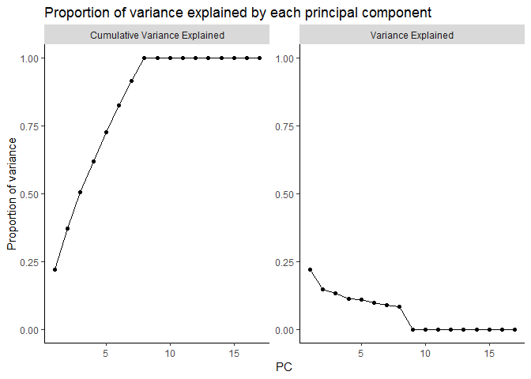

```r
plot_var_exp(resid_sv_var_exp)
```

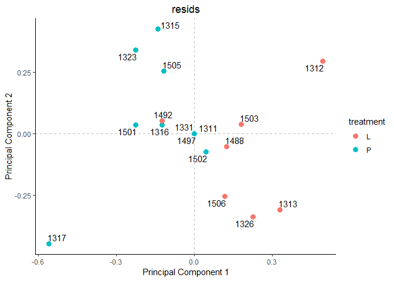

```r
plot_pca(resid_sv_pca, "resids", "treatment")
```

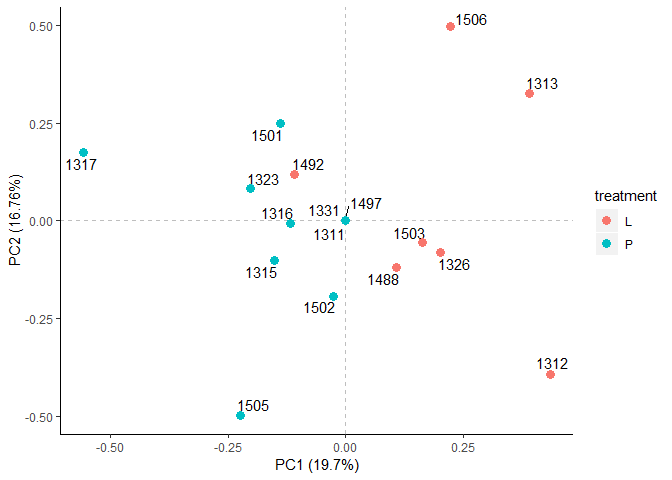

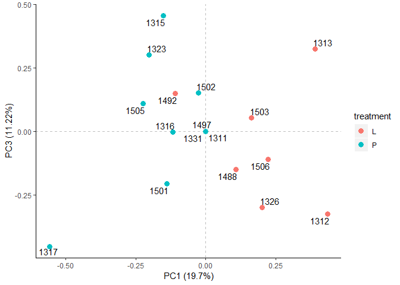

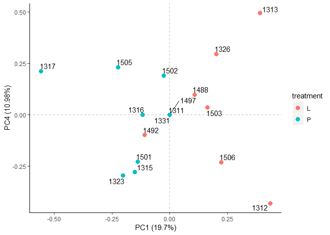

```r
plot_multiple_PCAs(resid_pca, 1, 4, "treatment")
```

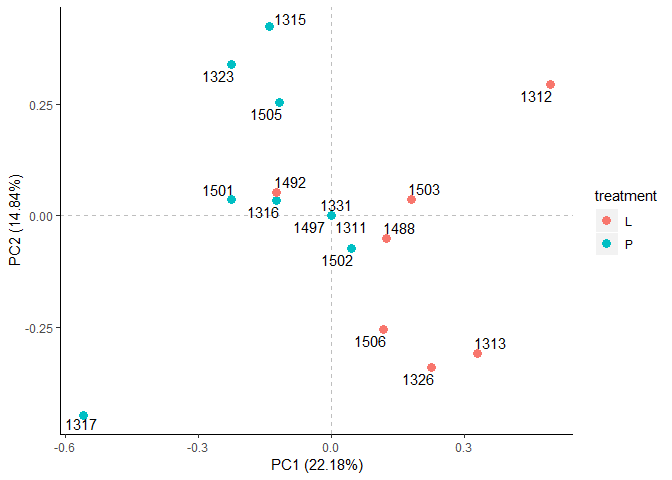

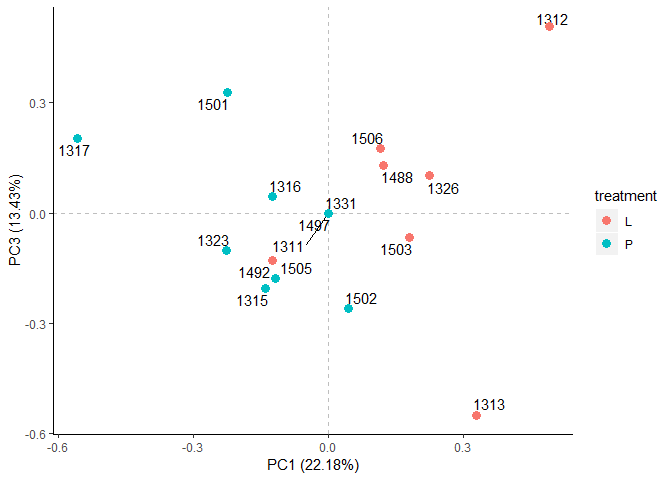

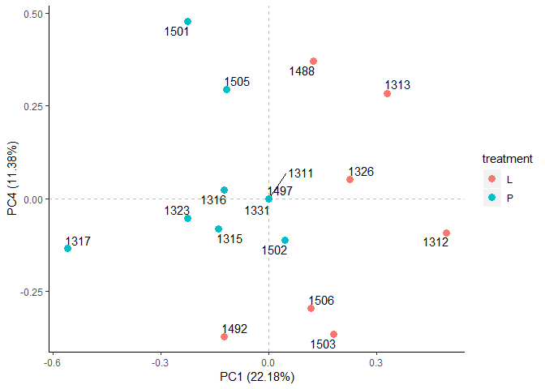

```r
plot_multiple_PCAs(resid_sv_pca, 1, 4, "treatment")
```

# t-test

Perform multiple t-test.

```r
residuals_sv_ttest <- multiple_ttests(residuals_sv, treatment,
                group_1 = L,
                group_2 = P,
                mean_1 = mean_L,
                mean_2 = mean_P,
                values = resid,
                equal_var = TRUE)
```

Plot p-value histogram.

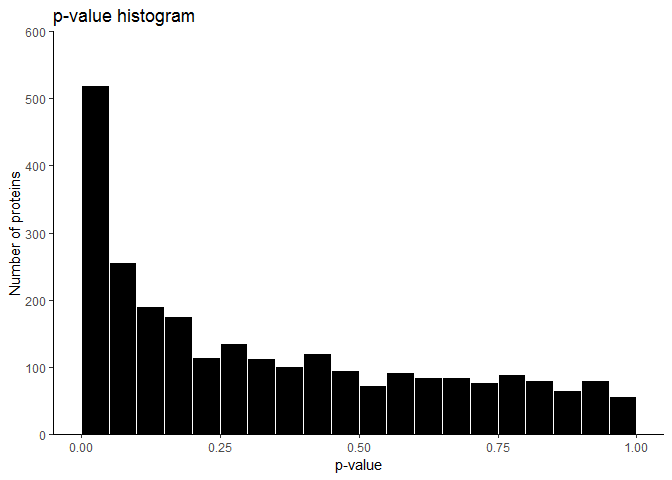

```r
plot_pvalue_histogram(residuals_sv_ttest, p_value, limit_max = 600)
```

```r
fdr_correction_with_qvalue <- function(tb, p_value_col) {

  # Quote
  p_value_col <- enquo(p_value_col)

  # fdr correction
  qvalues <- qvalue(as_vector(tb %>%
                                ungroup() %>% # To make sure to only get one column
                                dplyr::select(!!p_value_col)))

  return(qvalues)
}
```

FDR correction

```r
q_vals <- fdr_correction_with_qvalue(residuals_sv_ttest, p_value)
```

```r
resids_ttest <- multiple_ttests(resids_sv, treatment,
                group_1 = L,
                group_2 = P,
                mean_1 = mean_L,
                mean_2 = mean_P,
                values = resid,
                equal_var = TRUE)
```